```r
library(tidyverse)
```

```r
library(broom)
library(haven)
library(ggplot2)
```

Calculate mortality rates in units of deaths per 100,000 person-years. For example, the rate of death per 100,000 person-years from any cause can be calculated as `cod_any = 100000 * cod_any / (pop / 12)`

```r
data <- read_dta("all.dta")
f1 <- function(x)
  {
  cod =100000*x/(data$pop/12)
}
data1 <- sapply(data[,-c(1,15)], f1)
data1 <- cbind(data$agemo_mda, data1, data$pop)
colnames(data1)[1] <- "agemo_mda"
colnames(data1)[15] <- "pop"
data1 <- as.data.frame(data1)

names(data1)
```

```
##  [1] "agemo_mda"              "cod_any"                "cod_homicide"
##  [4] "cod_MVA"                "cod_extother"           "cod_external"
##  [7] "cod_internal"           "cod_sa"                 "cod_sa_firearms"
## [10] "cod_sa_poisoning"       "cod_sa_poisoning_subst" "cod_sa_poisoning_gas"
## [13] "cod_sa_drowning"        "cod_sa_other"           "pop"
```

```r
head(data1)
```

```
##   agemo_mda  cod_any cod_homicide  cod_MVA cod_extother cod_external
## 1       -48 17.32913    0.8321077 4.141187   0.09675671     8.533942
## 2       -47 17.87096    0.8127564 3.783187   0.08708104     8.572645
## 3       -46 17.99675    0.8514591 3.812214   0.06772970     8.475888
## 4       -45 17.94843    0.8321104 3.773524   0.10643272     8.708132
## 5       -44 19.09016    0.8224347 4.315363   0.09675702     9.317701
## 6       -43 19.50622    0.9772459 4.257309   0.09675702     9.888567
##   cod_internal   cod_sa cod_sa_firearms cod_sa_poisoning cod_sa_poisoning_subst
## 1     8.795185 3.463890       0.4160539        0.1451351             0.09675671
## 2     9.298320 3.889620       0.7159997        0.1644864             0.08708104
## 3     9.520861 3.744485       0.6095673        0.1161081             0.08708104
## 4     9.240295 3.996065       0.7837319        0.1741626             0.11610842
## 5     9.772459 4.083146       0.7934076        0.2322168             0.11610842
## 6     9.617648 4.557256       0.9578945        0.1935140             0.11610842
##   cod_sa_poisoning_gas cod_sa_drowning cod_sa_other       pop
## 1           0.04837836       0.8224321     2.080269 124022403
## 2           0.07740537       0.9288644     2.080269 124022403
## 3           0.02902701       0.9191888     2.099621 124022403
## 4           0.05805421       0.7547047     2.283466 124022010
## 5           0.11610842       0.7547047     2.302817 124022010
## 6           0.07740562       0.9095160     2.496331 124022010
```

1. Calculate mortality rates due to any cause for individuals in the sample who are 1–24 months above the MLDA and for those who are 1–24 months below the MLDA. Does this difference between these two groups plausibly describe the causal effect of reaching the MLDA on mortality? Why or why not?

```r
filter(data1, (data1$agemo_mda>=1) & (data1$agemo_mda <= 24))$cod_any
```

```
##  [1] 50.54650 53.69373 55.74590 55.23088 56.58519 57.66004 59.26092 60.68401
##  [9] 60.27850 61.25996 61.97921 63.20717 64.79209 67.08881 64.82126 68.61753
## [17] 69.79437 68.53151 70.52464 72.12387 72.20975 74.82508 76.49680 78.28526
```

```r
filter(data1, (data1$agemo_mda>=-24) & (data1$agemo_mda <= -1))$cod_any
```

```
##  [1] 25.23544 26.06315 26.74649 27.68069 27.64219 28.97041 29.20921 31.62248
##  [9] 30.66026 31.38688 31.89638 33.14600 34.49380 34.26410 35.95816 37.48066
## [17] 36.19812 38.47606 39.27495 41.09146 41.72332 41.66907 42.94046 43.74507
```

```r
mean(filter(data1, (data1$agemo_mda>=1) & (data1$agemo_mda <= 24))$cod_any) - mean(filter(data1, (data1$agemo_mda>=-24) & (data1$agemo_mda <= -1))$cod_any)
```

```
## [1] 30.27784
```

Theory 1: No because the difference between the two groups is very large, the difference in their ages are two poles apart and almost 4 years which tells us that the both groups are exposed to different factors which results for the cause of mortality

2. Create a scatter plot showing mortality rates due to (a) any cause and (b) motor vehicle accidents. Use black squares as markers for any cause of death and blue circles as markers for mortality due to motor vehicle accidents. Limit the plot to people who are within 2 years of the MLDA. Add a vertical line at the age at which driving eligibility begins.

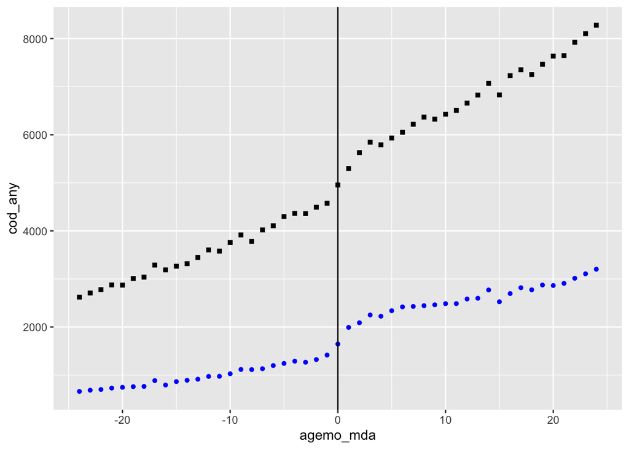

```r
data %>%
  filter((agemo_mda > -25) & (agemo_mda < 25)) %>%
  ggplot() +
  geom_point(aes(x = agemo_mda, y = cod_any), shape = 15, color = 'black') + #Any COD = Black Squares (15)
  geom_point(aes(x = agemo_mda, y = cod_MVA), shape = 16, color = 'blue') + #MVA = Blue Circles (16)
  geom_vline(xintercept = 0) # Vertical Line
```

3. Non-parametric “donut” RD. Calculate a non-parametric RD estimated effect of driving on mortality rates due to (a) any cause and (b) motor vehicle accidents. Calculate these estimates using four different bandwidths: 48, 24, 12, and 6 months. Omit the partially-treated observation `agemo_mda==0` from the estimation to generate what is called a “donut” RD. Use linear regression to calculate all these values, and report and describe this equation in your answer below. Report the results in a three-column table with 4 rows (one row per bandwidth). Column (1) should report the bandwidth, column (2) the RD estimate for all-cause mortality, and column (3) the RD estimate for motor vehicle accident mortality. Discuss whether/why point estimates and their precision change as the bandwidth becomes smaller.

```r
data1$Treat <-data1$agemo_mda >0
data1 <-filter(data1, data1$agemo_mda!=0)
data2 <-subset(data1, select = c(1,2,4,16))
arr_bdw<- c(48,24,12,6)
result<-data.frame(bandwidth = arr_bdw, rd_all = 1:4, rd_MVA = 1:4)
for (i in 1:4)
  {
  lm1 <- lm(cod_any ~Treat,data=subset(data2,abs(agemo_mda) <= result$bandwidth[i]))
  result$rd_all[i]<-lm1$coefficients["TreatTRUE"]
  lm2 <- lm(cod_MVA ~Treat,data=subset(data2,abs(agemo_mda) <= result$bandwidth[i]))
  result$rd_MVA[i]<-lm2$coefficients["TreatTRUE"]
}

result
```

```
##   bandwidth   rd_all    rd_MVA
## 1        48 48.83893 21.445071
## 2        24 30.27784 15.290869
## 3        12 19.06807 11.178446
## 4         6 13.16966  8.835371
```

3rd theory: From the above results we say that the RD estimates are going down by reducing the bandwidth, we can say that if bandwidth is large then the difference in groups is maximized due to the other factors which makes them two different types of population. Viceversa if you think about the low bandwidth it tells that the two groups are similar approximately except for fact that one is a treated and not treated.

4. RD. Calculate a parametric RD estimated effect of driving on mortality rates due to (a) any cause and (b) motor vehicle accidents. Allow for linear trends on either side of the cutoff. Calculate these estimates using four different bandwidths: 48, 24, 12, and 6 months. Omit the partially-treated observation `agemo_mda==0` from the estimation to perform a “donut” RD. Use linear regression to calculate all these values, and report and describe this equation in your answer below. Report the results in a three-column table with 4 rows (one row per bandwidth). Column (1) should report the bandwidth, column (2) the RD estimate for all-cause mortality, and column (3) the RD estimate for motor vehicle accident mortality. Discuss whether/why point estimates and their precision change as the bandwidth becomes smaller. How do these parametric estimates compare to the non-parametric RD estimates?

```r
data3 <- subset(data1, select = c(1,2,4,16))
data3$TreatAGE_cutoff <- data3$Treat * data3$agemo_mda
data3 <- data3[-25,]
arr_bdw<- c(48,24,12,6)
result <-data.frame(bandwidth =arr_bdw, rd_all=1:4, rd_MVA=1:4)
for (i in 1:4)
  {
  lm3 <- lm(cod_any ~Treat+agemo_mda +TreatAGE_cutoff, data=subset(data3,abs(agemo_mda)<= result$bandwidth[i]))
  result$rd_all[i] <- lm3$coefficients["TreatTRUE"]
  lm4 <- lm(cod_MVA ~Treat+agemo_mda +TreatAGE_cutoff,data=subset(data3,abs(agemo_mda) <=result$bandwidth[i]))
  result$rd_MVA[i]<-lm4$coefficients["TreatTRUE"]
}
result
```

```
##   bandwidth    rd_all   rd_MVA
## 1        48 11.834794 9.516126
## 2        24  6.831030 6.504842
## 3        12  6.611472 5.968510
## 4         6  6.012612 4.867183
```

4th Theory: After looking at the results for both parametric and non parametric, the non parametric values are larger than parametric. So, the parametric estimates can be considered to be a better estimate since they allowed the fitting of different curves above and below the cut off this makes theat different fits for treatment and control groups.